# BIS 567 Final Project

Jingchen Liang, Ruyi Liu

10/13/2022

```r
library(tidyverse)
library(rstan)
library(loo)
library(msm)
library(mnormt)
library(ggpubr)
library(corrplot)
#library(brms)
```

# Part 0. Data Import

```r
setwd("/Users/jingchen/Desktop/BIS 567/Final Project/")

alzheimer <- read.csv("ADNIMERGE.csv", na.strings = c("", "NA"))
dim(alzheimer)  ## 16186 obs & 116 cols
```

```
## [1] 16186   116
```

```r
colnames(alzheimer)
```

```
##   [1] "RID"                      "COLPROT"
##   [3] "ORIGPROT"                 "PTID"
##   [5] "SITE"                     "VISCODE"
##   [7] "EXAMDATE"                 "DX_bl"
##   [9] "AGE"                      "PTGENDER"
##  [11] "PTEDUCAT"                 "PTETHCAT"
##  [13] "PTRACCAT"                 "PTMARRY"
##  [15] "APOE4"                    "FDG"
##  [17] "PIB"                      "AV45"
##  [19] "FBB"                      "ABETA"
##  [21] "TAU"                      "PTAU"
##  [23] "CDRSB"                    "ADAS11"
##  [25] "ADAS13"                   "ADASQ4"
##  [27] "MMSE"                     "RAVLT_immediate"
##  [29] "RAVLT_learning"           "RAVLT_forgetting"
```

[output cut: 43 more lines]

# Part 1. Data Cleaning

Variables related to assessment scores:

- ADAS11, ADAS13, ADASQ4 (Alzheimer’s disease assessment score)
- CDR: Clinical Dementia Rating Scale
- DIGITSCOR: Digit Symbol Substitution
- ECog: Everyday Cognition
- FAQ: Functional Assessment Questionnaire
- LDELTOTAL: Delayed Recall Total
- MMSE: Mini Mental State Evaluation
- MOCA: Score Montreal Cognitive Assessment (MOCA) without Education Adjustment
- PACC: Preclinical Alzheimer’s Cognitive Composite
- RAVLT: Rey Auditory Verbal Learning Test
- TRABSCOR: Trail Making Test

Reference: https://www.stat.uci.edu/wp-content/uploads/Data-Analysis_FYQE_2021.pdf https://adni.bitbucket.io/reference/pacc.html https://adni.bitbucket.io/reference/scoreMOCA.html https://adni.bitbucket.io/reference/neurobat.html https://adni.bitbucket.io/reference/docs/UWNPSYCHSUM/ADNI_Methods_UWNPSYCHSUM_May_2018.pdf https://www.ncbi.nlm.nih.gov/pmc/articles/PMC4247808/ https://hardy-lab-statistical-genetics.github.io/p/introduction-to-adni-dataset/ https://adni.bitbucket.io/reference/faq.html https://adni.loni.usc.edu/wp-content/uploads/2008/07/inst_commonly_used_table.pdf https://ac209a-alzheimersproject.github.io/alzheimers-project/eda.html

Numeric Variables: ICV: intracranial volume Hippocampus = hippocampal volume Entorhinal = entorhinal cortex volume WholeBrain = entire brain volume MidTemp = middle temporal gyrus volumme

```r
# delete useless and repeated columns
alzheimer1 <- alzheimer[ , -which(names(alzheimer) %in% c("COLPROT","ORIGPROT","PTID","SITE","VISCODE","FLDSTRENG",
       "FSVERSION","IMAGEUID","FLDSTRENG_bl","FSVERSION_bl","IMAGEUID_bl","update_stamp","M","Month_bl"))]
# delete examination scores: ADAS11, ADAS13, ADASQ4, CDR, DIGITSCOR, ECog, FAQ, LDELTOTAL, MMSE, MOCA, PACC, RAVLT, TRABSCOR
alzheimer1 <- alzheimer1[ , -which(names(alzheimer1) %in% c("ADAS11","ADAS11_bl","ADAS13","ADAS13_bl","ADASQ4",
       "ADASQ4_bl","CDRSB","CDRSB_bl","DIGITSCOR","DIGITSCOR_bl","EcogPtDivatt","EcogPtDivatt_bl",
       "EcogPtLang","EcogPtLang_bl","EcogPtMem","EcogPtMem_bl","EcogPtOrgan","EcogPtOrgan_bl",
       "EcogPtPlan","EcogPtPlan_bl","EcogPtTotal","EcogPtTotal_bl","EcogPtVisspat","EcogPtVisspat_bl",
       "EcogSPDivatt","EcogSPDivatt_bl","EcogSPLang","EcogSPLang_bl","EcogSPMem","EcogSPMem_bl",
       "EcogSPOrgan","EcogSPOrgan_bl","EcogSPPlan","EcogSPPlan_bl","EcogSPTotal","EcogSPTotal_bl",
       "EcogSPVisspat","EcogSPVisspat_bl","FAQ","FAQ_bl","LDELTOTAL","LDELTOTAL_BL","MMSE","MMSE_bl",
       "MOCA","MOCA_bl","mPACCdigit","mPACCdigit_bl","mPACCtrailsB","mPACCtrailsB_bl","RAVLT_forgetting",
       "RAVLT_forgetting_bl","RAVLT_immediate","RAVLT_immediate_bl","RAVLT_learning","RAVLT_learning_bl",
       "RAVLT_perc_forgetting","RAVLT_perc_forgetting_bl","TRABSCOR","TRABSCOR_bl"))]
# sort the original data by RID, and the examination date for each patient
alzheimer1 <- alzheimer1[order(alzheimer1$RID, alzheimer1$EXAMDATE),]   # 16186 obs & 42 cols
# delete all rows if a patient only have one record - all records with Month = 0
one_record <- as.data.frame(alzheimer1 %>% group_by(RID) %>% tally())
alzheimer2 <- alzheimer1[which(!alzheimer1$RID %in% one_record$RID[which(one_record$n == 1)]),]  # 15930 obs & 42 cols
# check if any baseline diagnostic information is missing for each patient - all have been deleted
first_diag_miss <- alzheimer2[which(alzheimer2$Month == 0),][,c("RID","DX")]
dim(alzheimer2[which(alzheimer2$RID %in% first_diag_miss$RID[is.na(first_diag_miss$DX)]),])
```

```
## [1]  0 42
```

```r
# recreate the baseline diagnosis (Month = number of months since baseline visit: baseline visit is month 0)
first_diag <- alzheimer2[which(alzheimer2$Month == 0),][,c("RID","DX")]
colnames(first_diag) <- c("RID","DX_bl_new")
alzheimer3 <- merge(alzheimer2,first_diag,by="RID")  # 15930 obs & 42 cols
alzheimer3$DX_bl <- NULL
# check if any last diagnostic information is missing for each patient - 778 patients
last_diag_miss <- alzheimer3 %>% group_by(RID) %>% arrange(EXAMDATE) %>% slice(n())
# delete missing rows separately: last record missing or non-missing patients, then combine the data
# if there are only two rows for each patients, we will remove all rows
# if there are more than two rows, we go backward in time to find the record that is not missing. If there are
# still missing values up to the baseline, we delete all records for that patient.
# (1) for patients last record missing
last_miss_subset <- alzheimer3[which(alzheimer3$RID %in%
                              last_diag_miss$RID[is.na(last_diag_miss$DX)]),]
last_miss_subset1 <- last_miss_subset[which(!is.na(last_miss_subset$DX)),]  # no missing for DX in this dataset
# if only one record, delete
one_record1 <- as.data.frame(last_miss_subset1 %>% group_by(RID) %>% tally())
last_miss_subset2 <- last_miss_subset1[which(!last_miss_subset1$RID %in% one_record1$RID[which(one_record1$n == 1)]),]
# (2) for patients last record non-missing
rest_miss_subset <- alzheimer3[which(!alzheimer3$RID %in%
                              last_diag_miss$RID[is.na(last_diag_miss$DX)]),]
rest_miss_subset1 <- rest_miss_subset[which(!is.na(rest_miss_subset$DX)),]  # no missing for DX in this dataset
# if only one record, delete
one_record2 <- as.data.frame(rest_miss_subset1 %>% group_by(RID) %>% tally())
sum(one_record2$n == 1)  # all have at least 2 records
```

```
## [1] 0
```

```r
# combine the data - no missing values for DX or DX_bl_new in alzheimer4, and each patient has at least 2 records
alzheimer4 <- rbind(rest_miss_subset1,last_miss_subset2)   # # 10987 obs & 42 cols
length(unique(alzheimer4$RID))  # 2061 unique patients
```

```
## [1] 2061
```

```r
sort(colSums(sapply(alzheimer4[which(colSums(is.na(alzheimer4)) > 0)], is.na)), decreasing = TRUE)
```

```
##         PIB_bl            PIB            FBB         FBB_bl           PTAU
##          10877          10766          10592          10360           8664
##          ABETA            TAU           AV45            FDG        AV45_bl
##           8663           8663           8033           7404           5808
##       ABETA_bl         TAU_bl        PTAU_bl     Entorhinal       Fusiform
##           4088           4088           4088           3654           3654
##        MidTemp         FDG_bl    Hippocampus     Ventricles     WholeBrain
##           3654           3271           3268           2646           2429
##            ICV  Entorhinal_bl    Fusiform_bl     MidTemp_bl Hippocampus_bl
##           2133           1554           1554           1554           1467
##  Ventricles_bl  WholeBrain_bl         ICV_bl          APOE4            AGE
##            478            282            146            107              6
```

```r
# variable selection 1
alzheimer5 <- alzheimer4[ , -which(names(alzheimer4) %in%
                 c("EXAMDATE","EXAMDATE_bl","PTMARRY","PIB","PIB_bl","FBB","FBB_bl","Fusiform","Fusiform_bl",
                   "Years_bl","ICV","ICV_bl","Ventricles","Ventricles_bl"))]
# "AV45","AV45_bl","FDG","FDG_bl","PTAU","PTAU_bl","ABETA","ABETA_bl","TAU","TAU_bl"
sort(colSums(sapply(alzheimer5[which(colSums(is.na(alzheimer5)) > 0)], is.na)), decreasing = TRUE)
```

```
##           PTAU          ABETA            TAU           AV45            FDG
##           8664           8663           8663           8033           7404
##        AV45_bl       ABETA_bl         TAU_bl        PTAU_bl     Entorhinal
##           5808           4088           4088           4088           3654
##        MidTemp         FDG_bl    Hippocampus     WholeBrain  Entorhinal_bl
##           3654           3271           3268           2429           1554
##     MidTemp_bl Hippocampus_bl  WholeBrain_bl          APOE4            AGE
##           1554           1467            282            107              6
```

```r
# change to numeric variables
alzheimer5$ABETA <- as.numeric(alzheimer5$ABETA)
alzheimer5$ABETA_bl <- as.numeric(alzheimer5$ABETA_bl)
alzheimer5$TAU <- as.numeric(alzheimer5$TAU)
alzheimer5$TAU_bl <- as.numeric(alzheimer5$TAU_bl)
alzheimer5$PTAU <- as.numeric(alzheimer5$PTAU)
alzheimer5$PTAU_bl <- as.numeric(alzheimer5$PTAU_bl)

# calculate the difference
alzheimer5$FDG_diff <- alzheimer5$FDG - alzheimer5$FDG_bl
alzheimer5$FDG <- NULL
alzheimer5$FDG_bl <- NULL
alzheimer5$AV45_diff <- alzheimer5$AV45 - alzheimer5$AV45_bl
alzheimer5$AV45 <- NULL
alzheimer5$AV45_bl <- NULL
alzheimer5$ABETA_diff <- alzheimer5$ABETA - alzheimer5$ABETA_bl
alzheimer5$ABETA <- NULL
alzheimer5$ABETA_bl <- NULL
alzheimer5$TAU_diff <- alzheimer5$TAU - alzheimer5$TAU_bl
alzheimer5$TAU <- NULL
alzheimer5$TAU_bl <- NULL
alzheimer5$PTAU_diff <- alzheimer5$PTAU - alzheimer5$PTAU_bl
alzheimer5$PTAU <- NULL
alzheimer5$PTAU_bl <- NULL
alzheimer5$Hippocampus_diff <- alzheimer5$Hippocampus - alzheimer5$Hippocampus_bl
alzheimer5$Hippocampus <- NULL
alzheimer5$Hippocampus_bl <- NULL
alzheimer5$WholeBrain_diff <- alzheimer5$WholeBrain - alzheimer5$WholeBrain_bl
alzheimer5$WholeBrain <- NULL
alzheimer5$WholeBrain_bl <- NULL
alzheimer5$Entorhinal <- alzheimer5$Entorhinal - alzheimer5$Entorhinal_bl
alzheimer5$Entorhinal <- NULL
alzheimer5$Entorhinal_bl <- NULL
alzheimer5$MidTemp_diff <- alzheimer5$MidTemp - alzheimer5$MidTemp_bl
alzheimer5$MidTemp <- NULL
alzheimer5$MidTemp_bl <- NULL
# variable selection 2
alzheimer6 <- alzheimer5[ , -which(names(alzheimer5) %in%
                 c("ABETA_diff","PTAU_diff","TAU_diff","AV45_diff"))]
alzheimer7 <- alzheimer6[complete.cases(alzheimer6), ]  # no missing in this dataset
# colSums(is.na(alzheimer7))
# only select the last record for each patient
alzheimer8 <- as.data.frame(alzheimer7 %>% group_by(RID) %>% slice(n()))
alzheimer_final <- alzheimer8[which(alzheimer8$Month != 0),]
# create an outcome progression variable Y to indicate the presence or absence of disease progression
# no patients from Dementia to CN or from Dementia to MCI, but 18 patients from MCI to CN
# alzheimer_final[which(alzheimer_final$DX == "MCI" & alzheimer_final$DX_bl_new == "Dementia"),]
# alzheimer_final[which(alzheimer_final$DX == "CN" & alzheimer_final$DX_bl_new == "Dementia"),]
alzheimer_final$Y <- ifelse(alzheimer_final$DX == alzheimer_final$DX_bl_new, 0,
                    ifelse(alzheimer_final$DX == "CN" & alzheimer_final$DX_bl_new == "MCI", 0 ,1))
# 561 patients
nrow(alzheimer_final)
```

```
## [1] 561
```

```r
# store the clean data
# write.csv(alzheimer_final, "/Users/Jingchen/Desktop/alzheimer_final.csv", row.names = FALSE)
```

```r
#df <- read.csv(file = '/Users/jingchen/Desktop/alzheimer_final.csv', header = TRUE)
df <- alzheimer_final
head(df)
```

|  | RID | AGE | PTGENDER | PTEDUCAT | PTETHCAT | PTRACCAT | APOE4 | DX | Month | DX_bl_new | FDG_diff | Hippocampus_diff | WholeBrain_diff | MidTemp_diff | Y |
| --- | --- | --- | --- | --- | --- | --- | --- | --- | --- | --- | --- | --- | --- | --- | --- |
| 2 | 3 | 81.3 | Male | 18 | Not Hisp/Latino | White | 1 | Dementia | 24 | Dementia | -0.064330 | -180 | -41270 | -2024 | 0 |
| 3 | 5 | 73.7 | Male | 16 | Not Hisp/Latino | White | 0 | CN | 36 | CN | 0.033040 | -680 | -36140 | -1216 | 0 |
| 4 | 8 | 84.5 | Female | 18 | Not Hisp/Latino | White | 0 | CN | 6 | CN | -0.010380 | -40 | -8778 | -921 | 0 |
| 5 | 10 | 73.9 | Female | 12 | Not Hisp/Latino | White | 1 | Dementia | 24 | Dementia | -0.164723 | -617 | -44387 | -1722 | 0 |
| 6 | 14 | 78.5 | Female | 12 | Hisp/Latino | White | 0 | CN | 36 | CN | 0.043840 | -210 | -36214 | -1191 | 0 |
| 7 | 16 | 65.4 | Male | 9 | Not Hisp/Latino | Black | 1 | CN | 36 | CN | -0.103100 | -226 | -34952 | -2265 | 0 |

```r
dim(df)
```

```
## [1] 561  15
```

```r
# reformat the variables
# 1. Gender: Male = 1, Female = 0
df$Gender <- ifelse(df$PTGENDER == "Male", 1, 0)
df$PTGENDER <- NULL
df$DX_bl_new <- NULL
df$DX <- NULL
df$Month <- NULL
df$PTETHCAT <- NULL
# 2. Race: White = 1, Non_White = 0
df$Race <- ifelse(df$PTRACCAT == "White", 1, 0)
df$PTRACCAT <- NULL
df <- df[,c(1:8,10:11,9)]
df$RID <- NULL
head(df)
```

|  | AGE | PTEDUCAT | APOE4 | FDG_diff | Hippocampus_diff | WholeBrain_diff | MidTemp_diff | Gender | Race | Y |
| --- | --- | --- | --- | --- | --- | --- | --- | --- | --- | --- |
| 2 | 81.3 | 18 | 1 | -0.064330 | -180 | -41270 | -2024 | 1 | 1 | 0 |
| 3 | 73.7 | 16 | 0 | 0.033040 | -680 | -36140 | -1216 | 1 | 1 | 0 |
| 4 | 84.5 | 18 | 0 | -0.010380 | -40 | -8778 | -921 | 0 | 1 | 0 |
| 5 | 73.9 | 12 | 1 | -0.164723 | -617 | -44387 | -1722 | 0 | 1 | 0 |
| 6 | 78.5 | 12 | 0 | 0.043840 | -210 | -36214 | -1191 | 0 | 1 | 0 |
| 7 | 65.4 | 9 | 1 | -0.103100 | -226 | -34952 | -2265 | 1 | 0 | 0 |

```r
sd_mat <- scale(as.matrix(df[,-10]))
sd_df <- data.frame(sd_mat)
head(sd_df)
```

|  | AGE | PTEDUCAT | APOE4 | FDG_diff | Hippocampus_diff | WholeBrain_diff | MidTemp_diff | Gender | Race |
| --- | --- | --- | --- | --- | --- | --- | --- | --- | --- |
| 2 | 1.19085850 | 0.66542691 | 0.6842943 | -0.7531509 | 0.5141061 | -0.5294911 | -0.90430872 | 0.8085171 | 0.2693107 |
| 3 | 0.09686262 | -0.04427746 | -0.8211532 | 1.0876455 | -0.7033145 | -0.3509270 | -0.25463087 | 0.8085171 | 0.2693107 |
| 4 | 1.65148835 | 0.66542691 | -0.8211532 | 0.2667831 | 0.8549838 | 0.6014843 | -0.01743413 | -1.2346275 | 0.2693107 |
| 5 | 0.12565198 | -1.46368618 | 0.6842943 | -2.6510976 | -0.5499195 | -0.6379870 | -0.66148358 | -1.2346275 | 0.2693107 |
| 6 | 0.78780739 | -1.46368618 | -0.8211532 | 1.2918214 | 0.4410608 | -0.3535028 | -0.23452945 | -1.2346275 | 0.2693107 |
| 7 | -1.09789605 | -2.52824273 | 0.6842943 | -1.4861043 | 0.4021034 | -0.3095753 | -1.09808639 | 0.8085171 | -3.7065651 |

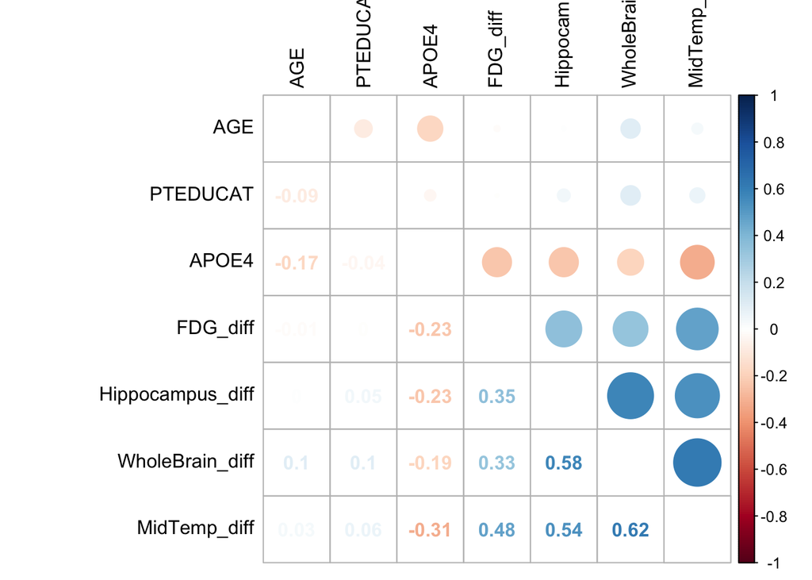

```r
# check correlations
corr_data <- df[,1:7]
brainCor <- cor(corr_data)
##Visualize correlations
corrplot.mixed(brainCor, tl.col="black", tl.pos = "lt")
```

# Part 2 Bayesian Analysis

## Model 1. Bayesian Logistic Regression

We have defined the log likelihood as a vector named log_lik in the generated quantities block so that the individual terms will be saved by Stan. After running Stan, log_lik can be extracted (using the extract_log_lik function provided in the loo package) as an SxN matrix, where S is the number of simulations (posterior draws) and N is the number of data points.

```r
# Model Organization & Posterior Sampling
# reference:
# https://medewitt.github.io/resources/stan_mult_linear_regression.html
# https://mc-stan.org/loo/articles/loo2-large-data.html
# http://mc-stan.org/loo/articles/loo2-with-rstan.html
# https://moodle2.units.it/pluginfile.php/290156/mod_resource/content/1/stan-users-guide-2_19.pdf

x <- as.matrix(sd_df)
y <- df$Y
p = 9
n = 561

logit_reg_data <- list(y=y, N=n, x=x, P = 9)

# Model Organization & Posterior Sampling
logit_reg_fit <- stan("/Users/jingchen/Desktop/BIS 567/Final Project/logistic_reg.stan",
                      data = logit_reg_data, iter = 100000, warmup = 10000, thin = 10, chains = 3)
```

```
## Trying to compile a simple C file
```

[output not shown]

```r
# Posterior Inference
# Summarize the posterior (including effective sample size (n_eff)
# and Gelman and Rubin diagnostic (Rhat))
print(logit_reg_fit, pars = "beta", probs = c(0.025, 0.5, 0.975))
```

```
## Inference for Stan model: logistic_reg.
## 3 chains, each with iter=1e+05; warmup=10000; thin=10;
## post-warmup draws per chain=9000, total post-warmup draws=27000.
##
##          mean se_mean   sd  2.5%   50% 97.5% n_eff Rhat
## beta[1] -0.04       0 0.13 -0.29 -0.04  0.22 26481    1
## beta[2]  0.14       0 0.13 -0.10  0.14  0.39 27147    1
## beta[3]  0.20       0 0.12 -0.04  0.20  0.44 26533    1
## beta[4] -0.36       0 0.14 -0.64 -0.36 -0.10 26783    1
## beta[5] -0.89       0 0.16 -1.21 -0.89 -0.57 27408    1
## beta[6]  0.09       0 0.17 -0.23  0.09  0.43 27277    1
## beta[7] -0.36       0 0.17 -0.69 -0.36 -0.04 26166    1
## beta[8]  0.09       0 0.13 -0.15  0.09  0.34 27767    1
## beta[9]  0.33       0 0.18  0.01  0.32  0.71 27300    1
##
## Samples were drawn using NUTS(diag_e) at Sun Dec  4 19:39:27 2022.
## For each parameter, n_eff is a crude measure of effective sample size,
## and Rhat is the potential scale reduction factor on split chains (at
## convergence, Rhat=1).
```

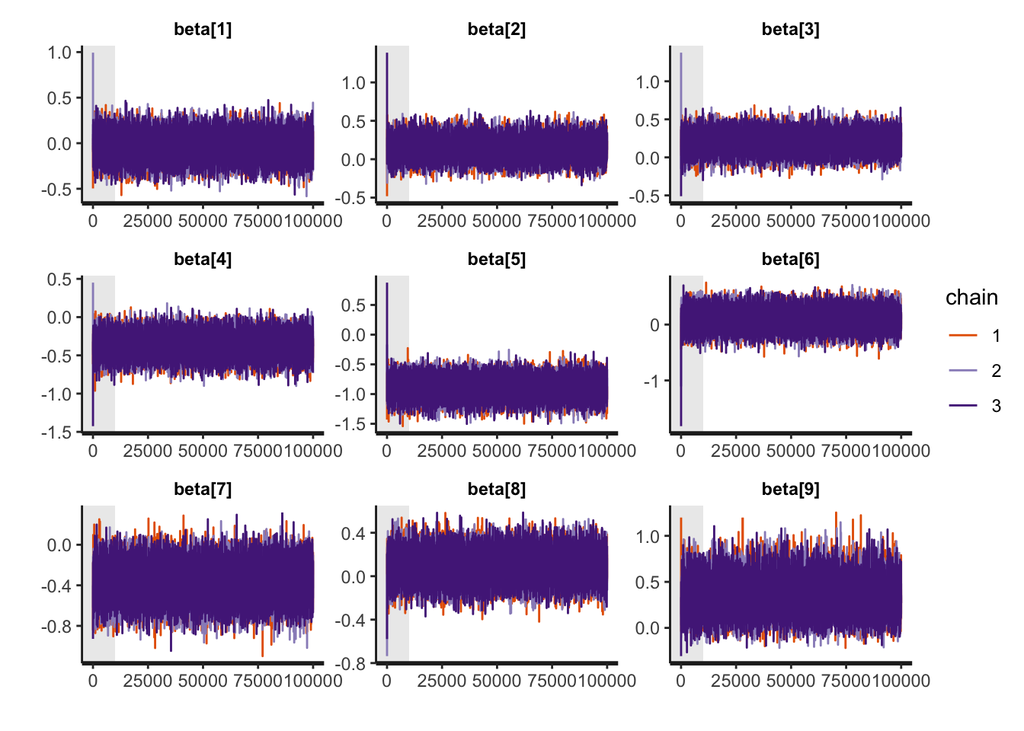

```r
# Trace plots
rstan::traceplot(logit_reg_fit, pars = "beta", inc_warmup=TRUE)
```

```r
# We can then use the loo package to compute the efficient PSIS-LOO approximation to exact LOO-CV
# Extract pointwise log-likelihood
# using merge_chains=FALSE returns an array, which is easier to
# use with relative_eff()
log_lik_1 <- extract_log_lik(logit_reg_fit, merge_chains = FALSE)

# as of loo v2.0.0 we can optionally provide relative effective sample sizes
# when calling loo, which allows for better estimates of the PSIS effective
# sample sizes and Monte Carlo error
r_eff <- relative_eff(exp(log_lik_1), cores = 2)

# preferably use more than 2 cores (as many cores as possible)
# will use value of 'mc.cores' option if cores is not specified
loo_1 <- loo(log_lik_1, r_eff = r_eff, cores = 2)
print(loo_1)
```

```
##
## Computed from 27000 by 561 log-likelihood matrix
##
##          Estimate   SE
## elpd_loo   -238.7 15.1
## p_loo        11.3  1.3
## looic       477.4 30.1
## ------
## Monte Carlo SE of elpd_loo is 0.0.
##
## All Pareto k estimates are good (k < 0.5).
## See help('pareto-k-diagnostic') for details.
```

The printed output from the `loo` function shows the estimates $\widehat{elpd}_{loo}$ (expected log predictive density), $\widehat{p}_{loo}$ (effective number of parameters), and looic = $-2\widehat{elpd}_{loo}$ (the LOO information criterion).

The line at the bottom of the printed output provides information about the reliability of the LOO approximation (the interpretation of the k parameter is explained in `help('pareto-k-diagnostic')` and in greater detail in Vehtari, Simpson, Gelman, Yao, and Gabry (2019)). In this case the message tells us that all of the estimates for k are fine.

## Model 2. Bayesian Probit Regression

```r
# Model Organization & Posterior Sampling
probit_reg_fit <- stan("/Users/jingchen/Desktop/BIS 567/Final Project/probit_reg.stan",
                      data = logit_reg_data, iter = 100000, warmup = 10000, thin = 10, chains = 3)
```

```
## Trying to compile a simple C file
```

[output not shown]

```r
# Posterior Inference
# Summarize the posterior (including effective sample size (n_eff)
# and Gelman and Rubin diagnostic (Rhat))
print(probit_reg_fit, pars = "beta", probs = c(0.025, 0.5, 0.975))
```

```
## Inference for Stan model: probit_reg.
## 3 chains, each with iter=1e+05; warmup=10000; thin=10;
## post-warmup draws per chain=9000, total post-warmup draws=27000.
##
##          mean se_mean   sd  2.5%   50% 97.5% n_eff Rhat
## beta[1] -0.01       0 0.07 -0.16 -0.01  0.13 26650    1
## beta[2]  0.05       0 0.07 -0.08  0.05  0.19 26577    1
## beta[3]  0.12       0 0.07 -0.01  0.12  0.26 26301    1
## beta[4] -0.19       0 0.08 -0.34 -0.19 -0.04 26808    1
## beta[5] -0.47       0 0.09 -0.65 -0.47 -0.30 26213    1
## beta[6]  0.04       0 0.09 -0.15  0.04  0.22 27317    1
## beta[7] -0.20       0 0.09 -0.38 -0.20 -0.02 26722    1
## beta[8]  0.06       0 0.07 -0.08  0.06  0.20 26400    1
## beta[9]  0.20       0 0.09  0.03  0.20  0.39 27150    1
##
## Samples were drawn using NUTS(diag_e) at Sun Dec  4 19:43:26 2022.
## For each parameter, n_eff is a crude measure of effective sample size,
## and Rhat is the potential scale reduction factor on split chains (at
## convergence, Rhat=1).
```

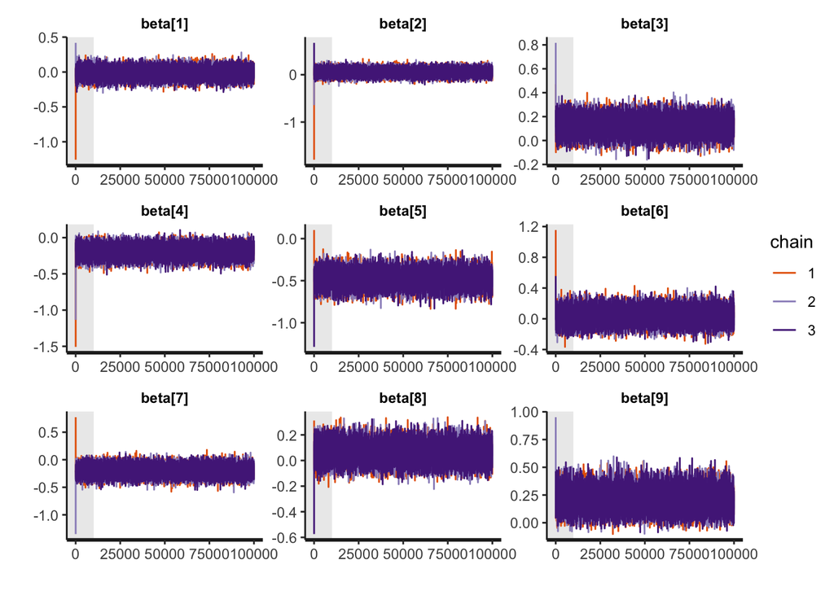

```r
# Trace plots
rstan::traceplot(probit_reg_fit, pars = "beta", inc_warmup=TRUE)
```

Cross-validation: (Leave-one-out cross-validation)  
rstanarm supports loo package which implements fast Pareto smoothed leave-one-out cross-validation (PSIS-LOO) (Vehtari, Gelman and Gabry, 2017b) to compute expected log predictive density (elpd):

```r
# We can then use the loo package to compute the efficient PSIS-LOO approximation to exact LOO-CV
# Extract pointwise log-likelihood
# using merge_chains=FALSE returns an array, which is easier to
# use with relative_eff()
log_lik_2 <- extract_log_lik(probit_reg_fit, merge_chains = FALSE)

# as of loo v2.0.0 we can optionally provide relative effective sample sizes
# when calling loo, which allows for better estimates of the PSIS effective
# sample sizes and Monte Carlo error
r_eff2 <- relative_eff(exp(log_lik_2), cores = 2)

# preferably use more than 2 cores (as many cores as possible)
# will use value of 'mc.cores' option if cores is not specified
loo_2 <- loo(log_lik_2, r_eff = r_eff2, cores = 2)
print(loo_2)
```

```
##
## Computed from 27000 by 561 log-likelihood matrix
##
##          Estimate   SE
## elpd_loo   -251.5  8.8
## p_loo         3.5  0.3
## looic       503.1 17.5
## ------
## Monte Carlo SE of elpd_loo is 0.0.
##
## All Pareto k estimates are good (k < 0.5).
## See help('pareto-k-diagnostic') for details.
```

## Variable Selection - Ridge Regression

```r
# Number of Posterior Samples
samples<-100000
# Prior Information
a<-0.01
b<-0.01
p<-9
# Parameters
beta2<-matrix(0, nrow=samples, ncol=p)
lambda2<-rep(0, times=samples)
neg_two_loglike2<-rep(0, times=samples)
# Initial Values
lambda2[1]<-1.00
# Main Sampling Loop
for(i in 2:samples){
   #w Parameters
   w<-(((1 - y)*rtnorm(n=n, mean=x%*%beta2[(i-1),], sd=1, lower=-Inf, upper=0)) +
      ((y)*rtnorm(n=n, mean=x%*%beta2[(i-1),], sd=1, lower=0, upper=Inf)))

   #beta Parameters
   beta_cov<-chol2inv(chol(t(x)%*%x + (1/lambda2[i-1])*diag(p)))
   beta_mean<-beta_cov%*%(t(x)%*%w)
   beta2[i,]<-rmnorm(n=1,
                     mean=beta_mean,
                     varcov=beta_cov)

   #lambda Parameter
   a_new<-(p/2) + a
   b_new<-t(beta2[i,])%*%beta2[i,]/2 + b
   lambda2[i]<-1/rgamma(n=1, shape=a_new, rate=b_new)

   #Print to the Screen
   #print(c("Completion Percentage:", round(100*(i/samples),3)))
}
```

```r
burnin<-10000
thin<-1
keep_set<-seq((burnin + 1), samples, thin)

est <- colMeans(beta2[keep_set,])
sd <- apply(beta2[keep_set,],2,sd)
quantile <- t(apply(beta2[keep_set,],2,quantile, probs=c(0.025,0.5,0.975)))
# create the table
res_table <- as.data.frame(cbind(est,sd,quantile))
rownames(res_table) <- c("AGE","PTEDUCAT","APOE4","FDG_diff","Hippocampus_diff",
                         "WholeBrain_diff","MidTemp_diff","Gender","Race")
colnames(res_table) <- c("est","sd","lower","median","upper")
res_table
```

|  | est | sd | lower | median | upper |
| --- | --- | --- | --- | --- | --- |
| AGE | -0.02315967 | 0.05422616 | -0.13008347 | -0.02322139 | 0.08288125 |
| PTEDUCAT | 0.05384591 | 0.05336421 | -0.04982869 | 0.05366366 | 0.15928551 |
| APOE4 | 0.07341097 | 0.05461062 | -0.03409803 | 0.07344263 | 0.18045526 |
| FDG_diff | -0.15019009 | 0.06023641 | -0.26982798 | -0.14956103 | -0.03313580 |
| Hippocampus_diff | -0.29357714 | 0.07100987 | -0.43604870 | -0.29220808 | -0.15763589 |
| WholeBrain_diff | -0.02827792 | 0.06970211 | -0.16354873 | -0.02875855 | 0.11031854 |
| MidTemp_diff | -0.15394386 | 0.06961782 | -0.29317526 | -0.15323686 | -0.01882844 |
| Gender | 0.02334988 | 0.05345032 | -0.08074186 | 0.02304875 | 0.12877281 |
| Race | 0.07378100 | 0.05465412 | -0.03067009 | 0.07287716 | 0.18324067 |

```r
beta_vals <- as.data.frame(beta2[keep_set,])
colnames(beta_vals)  <- c("AGE","PTEDUCAT","APOE4","FDG_diff","Hippocampus_diff",
                         "WholeBrain_diff","MidTemp_diff","Gender","Race")
```

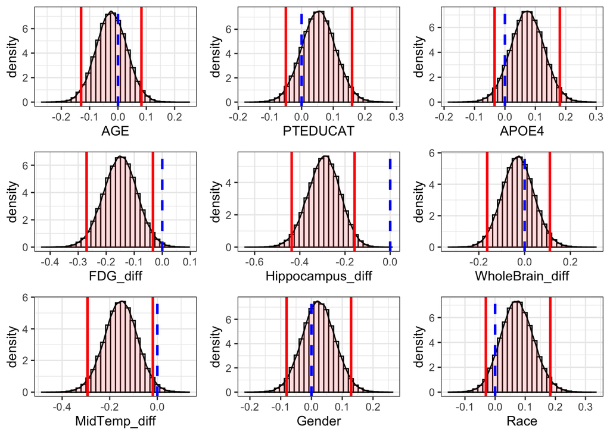

```r
# Histograms overlaid with kernel density curve
g1 <- ggplot(beta_vals, aes(x=AGE)) +
    geom_histogram(aes(y=..density..),      # Histogram with density instead of count on y-axis
                   bins=30,
                   colour="black", fill="white") +
    geom_density(alpha=.2, fill="#FF6666")  +   # Overlay with transparent density plot
    geom_vline(aes(xintercept=0), color="blue", linetype="dashed", size=1) +
    geom_vline(data = res_table[1,], aes(xintercept=lower), color="red", size=1) +
    geom_vline(data = res_table[1,], aes(xintercept=upper), color="red", size=1) + theme_bw()

g2 <- ggplot(beta_vals, aes(x=PTEDUCAT)) +
    geom_histogram(aes(y=..density..),      # Histogram with density instead of count on y-axis
                   bins=30,
                   colour="black", fill="white") +
    geom_density(alpha=.2, fill="#FF6666")  +   # Overlay with transparent density plot
    geom_vline(aes(xintercept=0), color="blue", linetype="dashed", size=1) +
    geom_vline(data = res_table[2,], aes(xintercept=lower), color="red", size=1) +
    geom_vline(data = res_table[2,], aes(xintercept=upper), color="red", size=1) + theme_bw()

g3 <- ggplot(beta_vals, aes(x=APOE4)) +
    geom_histogram(aes(y=..density..),      # Histogram with density instead of count on y-axis
                   bins=30,
                   colour="black", fill="white") +
    geom_density(alpha=.2, fill="#FF6666")  +   # Overlay with transparent density plot
    geom_vline(aes(xintercept=0), color="blue", linetype="dashed", size=1) +
    geom_vline(data = res_table[3,], aes(xintercept=lower), color="red", size=1) +
    geom_vline(data = res_table[3,], aes(xintercept=upper), color="red", size=1) + theme_bw()

g4 <- ggplot(beta_vals, aes(x=FDG_diff)) +
    geom_histogram(aes(y=..density..),      # Histogram with density instead of count on y-axis
                   bins=30,
                   colour="black", fill="white") +
    geom_density(alpha=.2, fill="#FF6666")  +   # Overlay with transparent density plot
    geom_vline(aes(xintercept=0), color="blue", linetype="dashed", size=1) +
    geom_vline(data = res_table[4,], aes(xintercept=lower), color="red", size=1) +
    geom_vline(data = res_table[4,], aes(xintercept=upper), color="red", size=1) + theme_bw()

g5 <- ggplot(beta_vals, aes(x=Hippocampus_diff)) +
    geom_histogram(aes(y=..density..),      # Histogram with density instead of count on y-axis
                   bins=30,
                   colour="black", fill="white") +
    geom_density(alpha=.2, fill="#FF6666")  +   # Overlay with transparent density plot
    geom_vline(aes(xintercept=0), color="blue", linetype="dashed", size=1) +
    geom_vline(data = res_table[5,], aes(xintercept=lower), color="red", size=1) +
    geom_vline(data = res_table[5,], aes(xintercept=upper), color="red", size=1) + theme_bw()

g6 <- ggplot(beta_vals, aes(x=WholeBrain_diff)) +
    geom_histogram(aes(y=..density..),      # Histogram with density instead of count on y-axis
                   bins=30,
                   colour="black", fill="white") +
    geom_density(alpha=.2, fill="#FF6666")  +   # Overlay with transparent density plot
    geom_vline(aes(xintercept=0), color="blue", linetype="dashed", size=1) +
    geom_vline(data = res_table[6,], aes(xintercept=lower), color="red", size=1) +
    geom_vline(data = res_table[6,], aes(xintercept=upper), color="red", size=1) + theme_bw()

g7 <- ggplot(beta_vals, aes(x=MidTemp_diff)) +
    geom_histogram(aes(y=..density..),      # Histogram with density instead of count on y-axis
                   bins=30,
                   colour="black", fill="white") +
    geom_density(alpha=.2, fill="#FF6666")  +   # Overlay with transparent density plot
    geom_vline(aes(xintercept=0), color="blue", linetype="dashed", size=1) +
    geom_vline(data = res_table[7,], aes(xintercept=lower), color="red", size=1) +
    geom_vline(data = res_table[7,], aes(xintercept=upper), color="red", size=1) + theme_bw()

g8 <- ggplot(beta_vals, aes(x=Gender)) +
    geom_histogram(aes(y=..density..),      # Histogram with density instead of count on y-axis
                   bins=30,
                   colour="black", fill="white") +
    geom_density(alpha=.2, fill="#FF6666")  +   # Overlay with transparent density plot
    geom_vline(aes(xintercept=0), color="blue", linetype="dashed", size=1) +
    geom_vline(data = res_table[8,], aes(xintercept=lower), color="red", size=1) +
    geom_vline(data = res_table[8,], aes(xintercept=upper), color="red", size=1) + theme_bw()

g9 <- ggplot(beta_vals, aes(x=Race)) +
    geom_histogram(aes(y=..density..),      # Histogram with density instead of count on y-axis
                   bins=30,
                   colour="black", fill="white") +
    geom_density(alpha=.2, fill="#FF6666")  +   # Overlay with transparent density plot
    geom_vline(aes(xintercept=0), color="blue", linetype="dashed", size=1) +
    geom_vline(data = res_table[9,], aes(xintercept=lower), color="red", size=1) +
    geom_vline(data = res_table[9,], aes(xintercept=upper), color="red", size=1) + theme_bw()

graphs <- ggarrange(g1,g2,g3,g4,g5,g6,g7,g8,g9,ncol=3,nrow=3)
graphs
```

## Model 3. Bayesian Logistic Regression

```r
# Model Organization & Posterior Sampling
x1 <- sd_df[,c("FDG_diff","Hippocampus_diff","MidTemp_diff")]
x1$FDG_Hipp <- x1$FDG_diff*x1$Hippocampus_diff
x1$FDG_MidTemp <- x1$FDG_diff*x1$MidTemp_diff
x1$Hipp_MidTemp <- x1$Hippocampus_diff*x1$MidTemp_diff
x1 <- as.matrix(x1)
logit_reg_data2 <- list(y=y, N=n, x=x1, P = 6)
logit_reg_fit2 <- stan("/Users/jingchen/Desktop/BIS 567/Final Project/logistic_reg.stan",
                      data = logit_reg_data2, iter = 100000, warmup = 10000, thin = 10, chains = 3)
# Posterior Inference
# Summarize the posterior (including effective sample size (n_eff)
# and Gelman and Rubin diagnostic (Rhat))
print(logit_reg_fit2, pars = "beta", probs = c(0.025, 0.5, 0.975))
```

```
## Inference for Stan model: logistic_reg.
## 3 chains, each with iter=1e+05; warmup=10000; thin=10;
## post-warmup draws per chain=9000, total post-warmup draws=27000.
##
##          mean se_mean   sd  2.5%   50% 97.5% n_eff Rhat
## beta[1] -0.55       0 0.16 -0.88 -0.55 -0.23 26150    1
## beta[2] -0.87       0 0.16 -1.18 -0.87 -0.57 26131    1
## beta[3] -0.24       0 0.16 -0.56 -0.24  0.09 26376    1
## beta[4] -0.36       0 0.15 -0.66 -0.36 -0.06 26644    1
## beta[5]  0.17       0 0.13 -0.08  0.17  0.43 26507    1
## beta[6]  0.13       0 0.14 -0.15  0.12  0.42 25495    1
##
## Samples were drawn using NUTS(diag_e) at Sun Dec  4 19:49:30 2022.
## For each parameter, n_eff is a crude measure of effective sample size,
## and Rhat is the potential scale reduction factor on split chains (at
## convergence, Rhat=1).
```

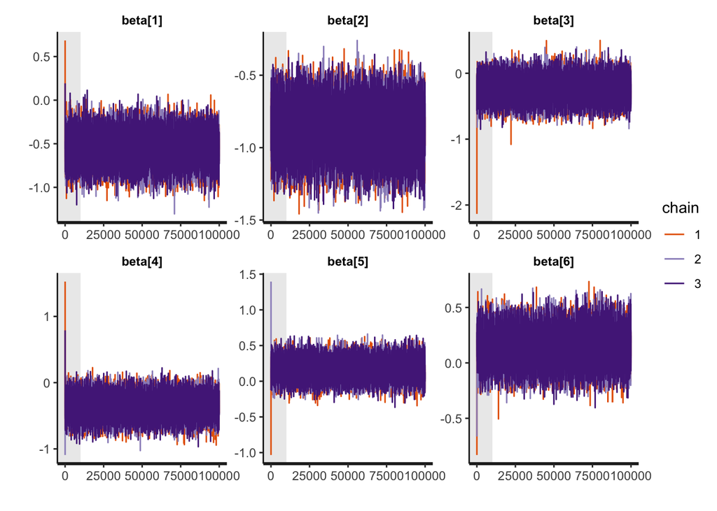

```r
# Trace plots
rstan::traceplot(logit_reg_fit2, pars = "beta", inc_warmup=TRUE)
```

```r
# We can then use the loo package to compute the efficient PSIS-LOO approximation to exact LOO-CV
# Extract pointwise log-likelihood
# using merge_chains=FALSE returns an array, which is easier to
# use with relative_eff()
log_lik_3 <- extract_log_lik(logit_reg_fit2, merge_chains = FALSE)

# as of loo v2.0.0 we can optionally provide relative effective sample sizes
# when calling loo, which allows for better estimates of the PSIS effective
# sample sizes and Monte Carlo error
r_eff3 <- relative_eff(exp(log_lik_3), cores = 2)

# preferably use more than 2 cores (as many cores as possible)
# will use value of 'mc.cores' option if cores is not specified
loo_3 <- loo(log_lik_3, r_eff = r_eff3, cores = 2)
print(loo_3)
```

```
##
## Computed from 27000 by 561 log-likelihood matrix
##
##          Estimate   SE
## elpd_loo   -237.8 15.0
## p_loo         8.8  2.2
## looic       475.7 30.0
## ------
## Monte Carlo SE of elpd_loo is NA.
##
## Pareto k diagnostic values:
##                          Count Pct.    Min. n_eff
## (-Inf, 0.5]   (good)     560   99.8%   17365
##  (0.5, 0.7]   (ok)         0    0.0%   <NA>
##    (0.7, 1]   (bad)        1    0.2%   495
##    (1, Inf)   (very bad)   0    0.0%   <NA>
## See help('pareto-k-diagnostic') for details.
```

## Model 4. Bayesian Probit Regression

```r
# Model Organization & Posterior Sampling
probit_reg_fit2 <- stan("/Users/jingchen/Desktop/BIS 567/Final Project/probit_reg.stan",
                      data = logit_reg_data2, iter = 100000, warmup = 10000, thin = 10, chains = 3)
# Posterior Inference
# Summarize the posterior (including effective sample size (n_eff)
# and Gelman and Rubin diagnostic (Rhat))
print(probit_reg_fit2, pars = "beta", probs = c(0.025, 0.5, 0.975))
```

```
## Inference for Stan model: probit_reg.
## 3 chains, each with iter=1e+05; warmup=10000; thin=10;
## post-warmup draws per chain=9000, total post-warmup draws=27000.
##
##          mean se_mean   sd  2.5%   50% 97.5% n_eff Rhat
## beta[1] -0.30       0 0.09 -0.47 -0.30 -0.13 26374    1
## beta[2] -0.46       0 0.08 -0.63 -0.46 -0.30 27296    1
## beta[3] -0.14       0 0.09 -0.32 -0.14  0.03 26702    1
## beta[4] -0.21       0 0.08 -0.38 -0.21 -0.06 26766    1
## beta[5]  0.09       0 0.07 -0.05  0.09  0.24 27417    1
## beta[6]  0.10       0 0.08 -0.05  0.09  0.25 26579    1
##
## Samples were drawn using NUTS(diag_e) at Sun Dec  4 19:54:11 2022.
## For each parameter, n_eff is a crude measure of effective sample size,
## and Rhat is the potential scale reduction factor on split chains (at
## convergence, Rhat=1).
```

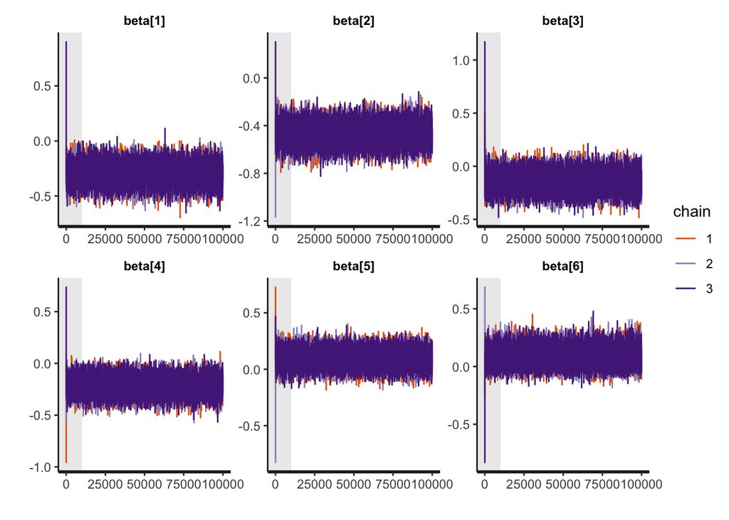

```r
# Trace plots
rstan::traceplot(probit_reg_fit2, pars = "beta", inc_warmup=TRUE)
```

```r
# We can then use the loo package to compute the efficient PSIS-LOO approximation to exact LOO-CV
# Extract pointwise log-likelihood
# using merge_chains=FALSE returns an array, which is easier to
# use with relative_eff()
log_lik_4 <- extract_log_lik(probit_reg_fit2, merge_chains = FALSE)

# as of loo v2.0.0 we can optionally provide relative effective sample sizes
# when calling loo, which allows for better estimates of the PSIS effective
# sample sizes and Monte Carlo error
r_eff4 <- relative_eff(exp(log_lik_4), cores = 2)

# preferably use more than 2 cores (as many cores as possible)
# will use value of 'mc.cores' option if cores is not specified
loo_4 <- loo(log_lik_4, r_eff = r_eff4, cores = 2)
print(loo_4)
```

```
##
## Computed from 27000 by 561 log-likelihood matrix
##
##          Estimate   SE
## elpd_loo   -252.2  8.7
## p_loo         2.5  0.4
## looic       504.4 17.5
## ------
## Monte Carlo SE of elpd_loo is 0.0.
##
## All Pareto k estimates are good (k < 0.5).
## See help('pareto-k-diagnostic') for details.
```

## Model Comparison

We can now compare the models on LOO using the `loo_compare` function:

```r
# Compare logistic and probit
comparison_logit_probit <- loo_compare(loo_1, loo_2)
print(comparison_logit_probit) # can set simplify=FALSE for more detailed print output
```

```
##        elpd_diff se_diff
## model1   0.0       0.0
## model2 -12.8       6.6
```

```r
# Compare logistic and probit after variable selection
comparison_logit_probit2 <- loo_compare(loo_3, loo_4)
print(comparison_logit_probit2) # can set simplify=FALSE for more detailed print output
```

```
##        elpd_diff se_diff
## model1   0.0       0.0
## model2 -14.4       6.6
```

```r
# Compare logistic and probit after variable selection
comparison_logit_logit3 <- loo_compare(loo_1, loo_3)
print(comparison_logit_logit3) # can set simplify=FALSE for more detailed print output
```

```
##        elpd_diff se_diff
## model2  0.0       0.0
## model1 -0.9       3.9
```

```r
# summary elpd for four models
models <- c("Model1","Model2","Model3","Model4")
description <- c("logit","probit","logit_vs","probit_vs")
elpd_loo <- round(c(loo_1$estimates[1],loo_2$estimates[1],loo_3$estimates[1],loo_4$estimates[1]),1)
loo_table <- cbind(models,description,elpd_loo)
loo_table
```

```
##      models   description elpd_loo
## [1,] "Model1" "logit"     "-238.7"
## [2,] "Model2" "probit"    "-251.5"
## [3,] "Model3" "logit_vs"  "-237.8"
## [4,] "Model4" "probit_vs" "-252.2"
```

## Mean Squqre Predictive Error (best model)

```r
# reference: https://medium.com/@alex.pavlakis/making-predictions-from-stan-models-in-r-3e349dfac1ed
# find MSE for the best model
# Split into training and testing
set.seed(100)
N_train <- round(n*0.7)
N_test <- n-N_train
train_ind <- sample(c(1:n), size = N_train, replace = FALSE)
x_train <- x1[train_ind,]
x_test <- x1[-train_ind,]
y_train <- y[train_ind]
y_test <- y[-train_ind]

logit_reg_MSE <- list(x_train=x_train, y_train=y_train, N_train=N_train,x_test=x_test, N_test=N_test, P = 6)

model3_MSE <- stan("/Users/jingchen/Desktop/BIS 567/Final Project/best_MSE.stan",
            data = logit_reg_MSE, chains = 3, iter = 100000, warmup = 10000, thin = 10)
```

```
## Trying to compile a simple C file
```

[output not shown]

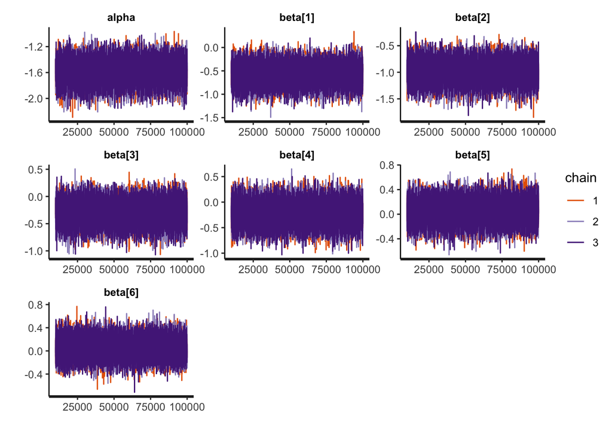

```r
rstan::traceplot(model3_MSE, pars = c("alpha", "beta"))
```

```r
ext_fit <- rstan::extract(model3_MSE)
mean(apply(ext_fit$y_test, 2, median) == y_test)
```

```
## [1] 0.8452381
```

The model converges and it the posterior distributions of the parameters are centered around their ‘true’ values. The accuracy of the model on new data is 0.85. This is a robust approach for making predictions for new data with Stan, but is impractical if predictions must be made frequently because it requires re-estimating the entire model every time new predictions need to be made.

```r
## option 1
# accuracy
ext_fit <- rstan::extract(model3_MSE)
accuracy_res <- mean(apply(ext_fit$y_test, 2, median) == y_test)
accuracy_res
```

```
## [1] 0.8452381
```

```r
# find MSE
y_test_res <- apply(ext_fit$y_test, 2, median)
MSE_res = mean((y_test_res-y_test)^2)
MSE_res
```

```
## [1] 0.1547619
```